# Identifying persons of interest in Enron dataset

```r
enron <- read.csv("final_project_dataset.csv", na.strings = "NaN")
```

```r
people_count = nrow(enron)
```

The dataset contains 14 financial features and 5 e-mail related features.

How does the data break into into POIs vs non-POIs?

```r
enron %>%
  group_by(poi) %>%
  summarize(count=n()) %>%
  mutate(prop=count/sum(count))
```

```
## Source: local data frame [2 x 3]
##
##     poi count      prop
## 1 False   128 0.8767123
## 2  True    18 0.1232877
```

Let’s get some summaries on the features in the dataset.

```r
summary(enron)
```

```
##                  name         salary          to_messages
##  ALLEN PHILLIP K   :  1   Min.   :     477   Min.   :   57.0
##  BADUM JAMES P     :  1   1st Qu.:  211816   1st Qu.:  541.2
##  BANNANTINE JAMES M:  1   Median :  259996   Median : 1211.0
##  BAXTER JOHN C     :  1   Mean   :  562194   Mean   : 2073.9
##  BAY FRANKLIN R    :  1   3rd Qu.:  312117   3rd Qu.: 2634.8
##  BAZELIDES PHILIP J:  1   Max.   :26704229   Max.   :15149.0
##  (Other)           :140   NA's   :51         NA's   :60
##  deferral_payments  total_payments      exercised_stock_options
##  Min.   : -102500   Min.   :      148   Min.   :     3285
##  1st Qu.:   81573   1st Qu.:   394475   1st Qu.:   527886
##  Median :  227449   Median :  1101393   Median :  1310814
##  Mean   : 1642674   Mean   :  5081526   Mean   :  5987054
##  3rd Qu.: 1002672   3rd Qu.:  2093263   3rd Qu.:  2547724
##  Max.   :32083396   Max.   :309886585   Max.   :311764000
##  NA's   :107        NA's   :21          NA's   :44
##      bonus          restricted_stock    shared_receipt_with_poi
##  Min.   :   70000   Min.   : -2604490   Min.   :   2.0
##  1st Qu.:  431250   1st Qu.:   254018   1st Qu.: 249.8
##  Median :  769375   Median :   451740   Median : 740.5
##  Mean   : 2374235   Mean   :  2321741   Mean   :1176.5
##  3rd Qu.: 1200000   3rd Qu.:  1002370   3rd Qu.:1888.2
##  Max.   :97343619   Max.   :130322299   Max.   :5521.0
##  NA's   :64         NA's   :36          NA's   :60
##  restricted_stock_deferred total_stock_value      expenses
##  Min.   :-7576788          Min.   :   -44093   Min.   :    148
##  1st Qu.: -389622          1st Qu.:   494510   1st Qu.:  22614
##  Median : -146975          Median :  1102872   Median :  46950
##  Mean   :  166411          Mean   :  6773957   Mean   : 108729
##  3rd Qu.:  -75010          3rd Qu.:  2949847   3rd Qu.:  79952
##  Max.   :15456290          Max.   :434509511   Max.   :5235198
##  NA's   :128               NA's   :20          NA's   :51
##  loan_advances      from_messages          other
##  Min.   :  400000   Min.   :   12.00   Min.   :       2
##  1st Qu.: 1600000   1st Qu.:   22.75   1st Qu.:    1215
##  Median :41762500   Median :   41.00   Median :   52382
##  Mean   :41962500   Mean   :  608.79   Mean   :  919065
##  3rd Qu.:82125000   3rd Qu.:  145.50   3rd Qu.:  362096
##  Max.   :83925000   Max.   :14368.00   Max.   :42667589
##  NA's   :142        NA's   :60         NA's   :53
##  from_this_person_to_poi    poi      director_fees     deferred_income
##  Min.   :  0.00          False:128   Min.   :   3285   Min.   :-27992891
##  1st Qu.:  1.00          True : 18   1st Qu.:  98784   1st Qu.:  -694862
##  Median :  8.00                      Median : 108579   Median :  -159792
##  Mean   : 41.23                      Mean   : 166805   Mean   : -1140475
##  3rd Qu.: 24.75                      3rd Qu.: 113784   3rd Qu.:   -38346
##  Max.   :609.00                      Max.   :1398517   Max.   :     -833
##  NA's   :60                          NA's   :129       NA's   :97
##  long_term_incentive                 email_address from_poi_to_this_person
##  Min.   :   69223    adam.umanoff@enron.com :  1   Min.   :  0.00
##  1st Qu.:  281250    a..martin@enron.com    :  1   1st Qu.: 10.00
##  Median :  442035    andrew.fastow@enron.com:  1   Median : 35.00
##  Mean   : 1470361    ben.glisan@enron.com   :  1   Mean   : 64.90
##  3rd Qu.:  938672    bill.cordes@enron.com  :  1   3rd Qu.: 72.25
##  Max.   :48521928    (Other)                :106   Max.   :528.00
##  NA's   :80          NA's                   : 35   NA's   :60
```

60 entries (~42%) don’t have any e-mail data.

Financial data is mixed, ~35% don’t have salary data, ~44% don’t have bonus data, 24% don’t have restricted stock data but every entry has at least some data under either payments or stocks.

## Financials

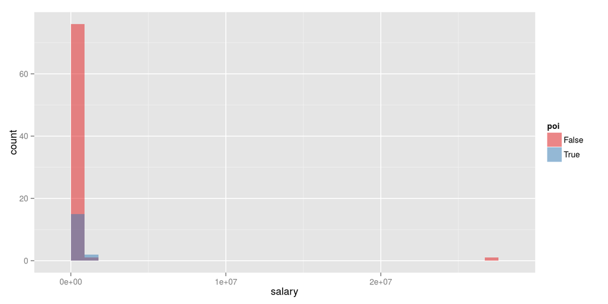

```r
ggplot(enron, aes(salary, fill=poi)) +
  geom_histogram(alpha=0.5, position="identity") +
  scale_fill_brewer(palette="Set1")
```

Some kind of outlier in the top graph.

```r
enron %>%
  arrange(desc(salary)) %>%
  select(name, salary) %>%
  head()
```

```
##                 name   salary
## 1              TOTAL 26704229
## 2 SKILLING JEFFREY K  1111258
## 3      LAY KENNETH L  1072321
## 4     FREVERT MARK A  1060932
## 5   PICKERING MARK R   655037
## 6 WHALLEY LAWRENCE G   510364
```

Let’s remove the ‘TOTAL’ data.

```r
enron <- enron %>%
  filter(name != "TOTAL")
```

Replot the salary data.

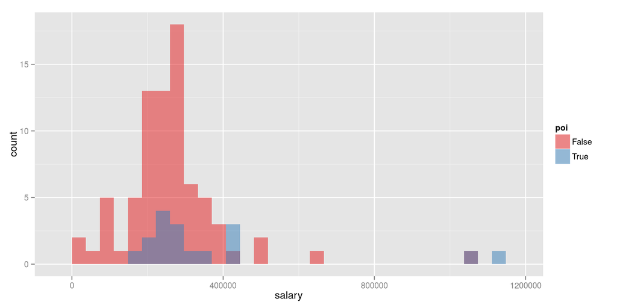

```r
ggplot(enron, aes(salary, fill=poi)) +
  geom_histogram(alpha=0.5, position="identity") +
  scale_fill_brewer(palette="Set1")
```

Looks better.

Let’s plot all the financial features and see how they compare between POIs and non-POIs.

[output not shown]

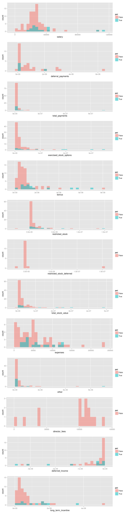

```r
financial_features=c(
  "salary",
  "deferral_payments",
  "total_payments",
  "exercised_stock_options",
  "bonus",
  "restricted_stock",
  "restricted_stock_deferred",
  "total_stock_value",
  "expenses",
  "other",
  "director_fees",
  "deferred_income",
  "long_term_incentive"
)

plots = lapply(financial_features, function(feature) {
  return(ggplot(enron, aes_string(feature, fill="poi")) +
           geom_histogram(alpha=0.5, position="identity"))
})

plots$ncol=1

do.call(grid.arrange, plots)
```

deferral_payments - noticeably different, worth a closer look, weird to see a value less than zero.

total_payments - outlier worth a closer look

exercised_stock_options - seems to be a feature worth trying

bonus - worth a try, not clear how useful it will be

restricted_stock - not interesting

restricted_stock_deferred - not interesting

total_stock_value - maybe expenses - not interesting

other - outlier worth a closer look

director_fees - not interesting

deferred_income - maybe

long_term_incentive - not interesting

```r
enron %>%
  arrange(deferral_payments) %>%
  select(name, deferral_payments) %>%
  head()
```

```
##              name deferral_payments
## 1   BELFER ROBERT           -102500
## 2  HAYES ROBERT E              7961
## 3    HIRKO JOSEPH             10259
## 4 THORN TERENCE H             16586
## 5  COLWELL WESLEY             27610
## 6     FUGH JOHN L             50591
```

```r
enron %>%
  filter(name=="BELFER ROBERT")
```

```
##            name salary to_messages deferral_payments total_payments
## 1 BELFER ROBERT     NA          NA           -102500         102500
##   exercised_stock_options bonus restricted_stock shared_receipt_with_poi
## 1                    3285    NA               NA                      NA
##   restricted_stock_deferred total_stock_value expenses loan_advances
## 1                     44093            -44093       NA            NA
##   from_messages other from_this_person_to_poi   poi director_fees
## 1            NA    NA                      NA False          3285
##   deferred_income long_term_incentive email_address
## 1              NA                  NA          <NA>
##   from_poi_to_this_person
## 1                      NA
```

The data for this person seems to be shifted columnwise. Let’s just ignore this row.

```r
enron <- enron %>%
  filter(name!="BELFER ROBERT")
```

```r
enron %>%
  arrange(desc(total_payments)) %>%
  select(name, total_payments) %>%
  head()
```

```
##                 name total_payments
## 1      LAY KENNETH L      103559793
## 2     FREVERT MARK A       17252530
## 3   BHATNAGAR SANJAY       15456290
## 4    LAVORATO JOHN J       10425757
## 5 SKILLING JEFFREY K        8682716
## 6    MARTIN AMANDA K        8407016
```

Doesn’t look like total_payments would do well to tell apart POIs.

```r
enron %>%
  arrange(desc(other)) %>%
  select(name, other) %>%
  head()
```

```
##              name    other
## 1   LAY KENNETH L 10359729
## 2  FREVERT MARK A  7427621
## 3 MARTIN AMANDA K  2818454
## 4   BAXTER JOHN C  2660303
## 5 SHERRIFF JOHN R  1852186
## 6       PAI LOU L  1829457
```

Outlier is Kenneth Lay again. If we ignore him, this feature doesn’t seem to a good indicator.

Let’s try using deferral_payments, exercised_stock_options, bonus, total_stock_value, deferred_income from financial features.

What if we look at fraction of payments/stock by type?

[output not shown]

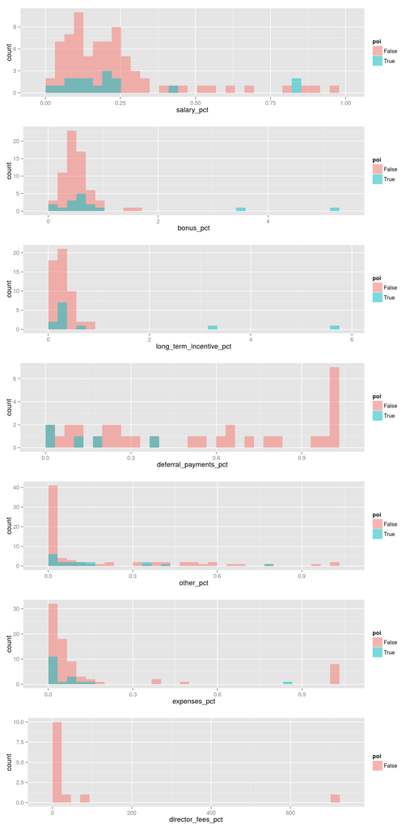

```r
enron <- enron %>%
  mutate(salary_pct=salary/total_payments,
         bonus_pct=bonus/total_payments,
         long_term_incentive_pct=long_term_incentive/total_payments,
         deferral_payments_pct=deferral_payments/total_payments,
         other_pct=other/total_payments,
         expenses_pct=expenses/total_payments,
         director_fees_pct=director_fees/total_payments)
financial_features=c(
  "salary_pct",
  "bonus_pct",
  "long_term_incentive_pct",
  "deferral_payments_pct",
  "other_pct",
  "expenses_pct",
  "director_fees_pct"
)

plots = lapply(financial_features, function(feature) {
  return(ggplot(enron, aes_string(feature, fill="poi")) +
           geom_histogram(alpha=0.5, position="identity"))
})
plots$ncol=1

do.call(grid.arrange, plots)
```

Overall, financial features appear to be weak indicators of POIs.

## E-mails

What about e-mail features?

to_messages shared_receipt_with_poi from_messages from_this_person_to_poi from_poi_to_this_person

[output not shown]

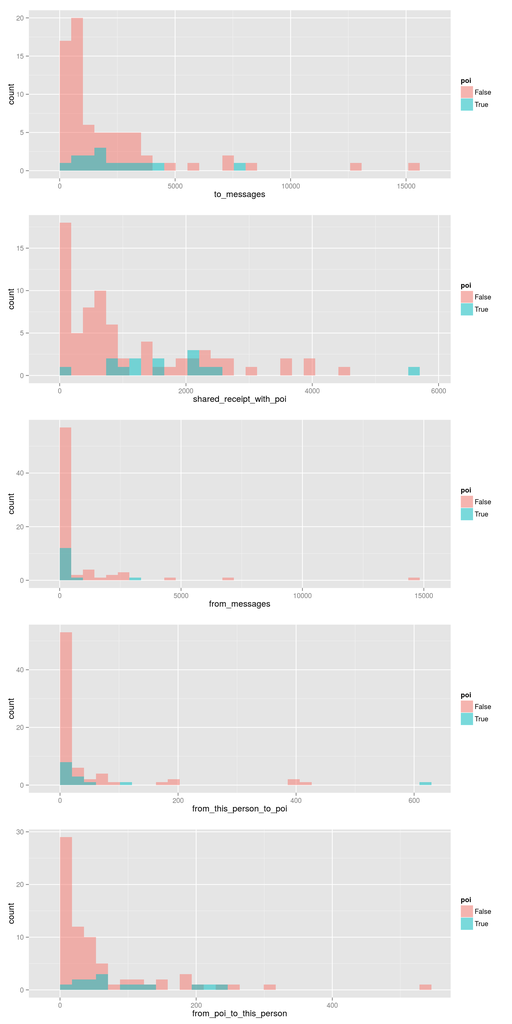

```r
g1 <- ggplot(enron, aes(to_messages, fill=poi)) + geom_histogram(alpha=0.5, position="identity")
g2 <- ggplot(enron, aes(shared_receipt_with_poi, fill=poi)) + geom_histogram(alpha=0.5, position="identity")
g3 <- ggplot(enron, aes(from_messages, fill=poi)) + geom_histogram(alpha=0.5, position="identity")
g4 <- ggplot(enron, aes(from_this_person_to_poi, fill=poi)) + geom_histogram(alpha=0.5, position="identity")
g5 <- ggplot(enron, aes(from_poi_to_this_person, fill=poi)) + geom_histogram(alpha=0.5, position="identity")

grid.arrange(g1, g2, g3, g4, g5, ncol=1)
```

None of these features look particularly interesting. What if we look at the percentage of emails from/to POI?

```r
enron <- enron %>%
  mutate(from_this_person_to_poi_pct = from_this_person_to_poi / from_messages,
         from_poi_to_this_person_pct = from_poi_to_this_person / to_messages)
```

```
## stat_bin: binwidth defaulted to range/30. Use 'binwidth = x' to adjust this.
```

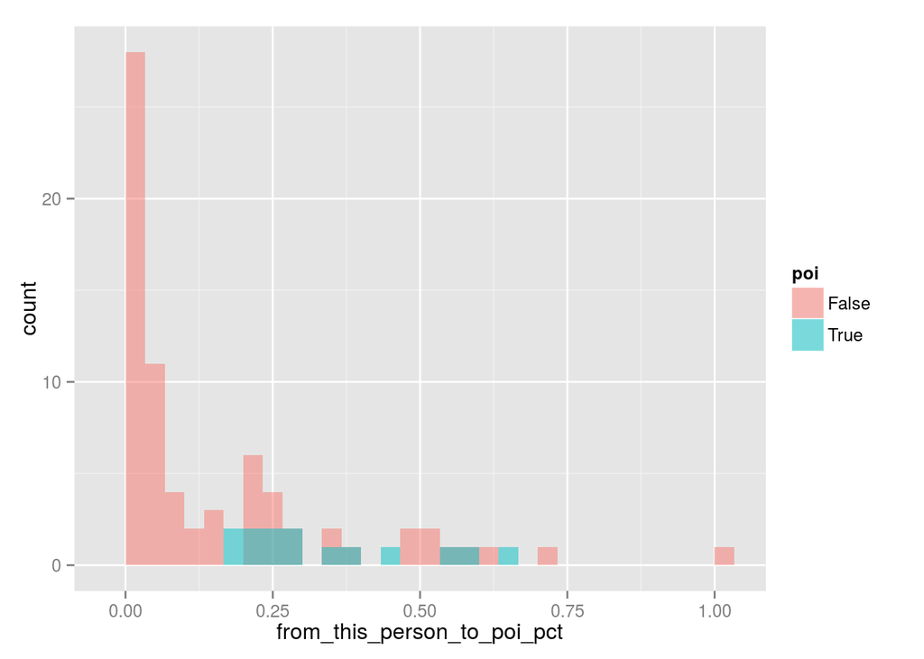

```r
ggplot(enron, aes(from_this_person_to_poi_pct, fill=poi)) + geom_histogram(alpha=0.5, position="identity")
```

```
## stat_bin: binwidth defaulted to range/30. Use 'binwidth = x' to adjust this.
```

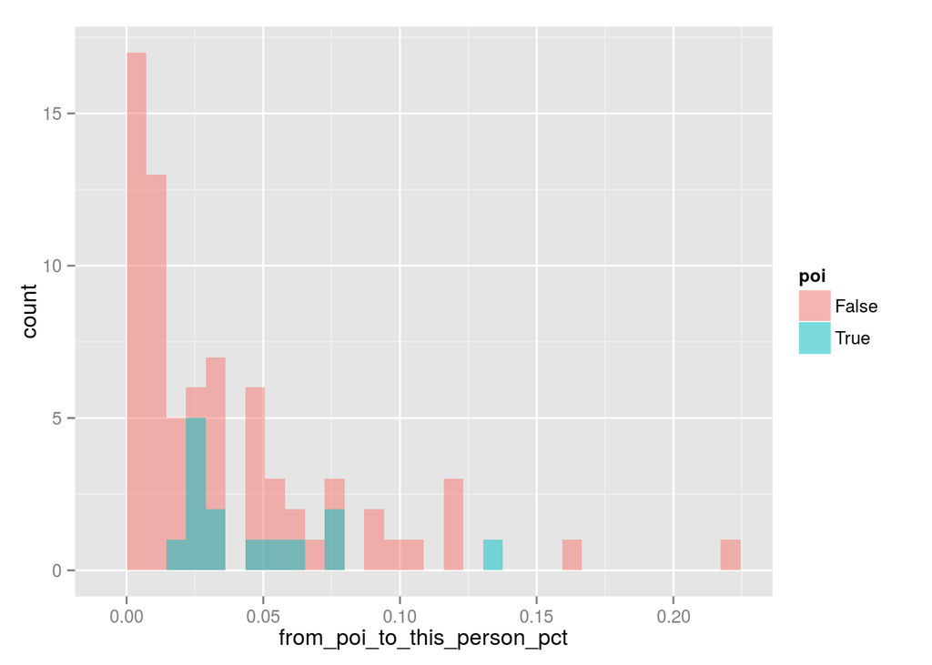

```r
ggplot(enron, aes(from_poi_to_this_person_pct, fill=poi)) + geom_histogram(alpha=0.5, position="identity")
```

from_this_person_to_poi_pct might be useful, but again none of the email features appear to be great indicators of POIs.